# Project 2D

### Homology Modeling and Structural Bioinformatics

##### PyMOL

PyMOL is a program created that presented visual 3D representations of various molecular protein structures based off of their codes. It provides an assisted interface that can be used in various ways to provide analysis of the structures. Below are the PyMOL images of the 7K3G and 5X29, SARS-CoV-2 and SARS-CoV, in that order. I have included this for a basic visual, seperating the colors based on the chains of the protein. This sets as a precedent before overlaying both of the structures to analyze for similarities.

##### 7K3G

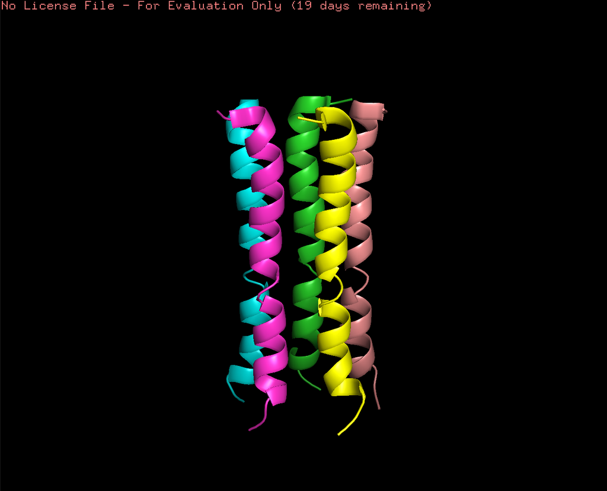

###### 5X29

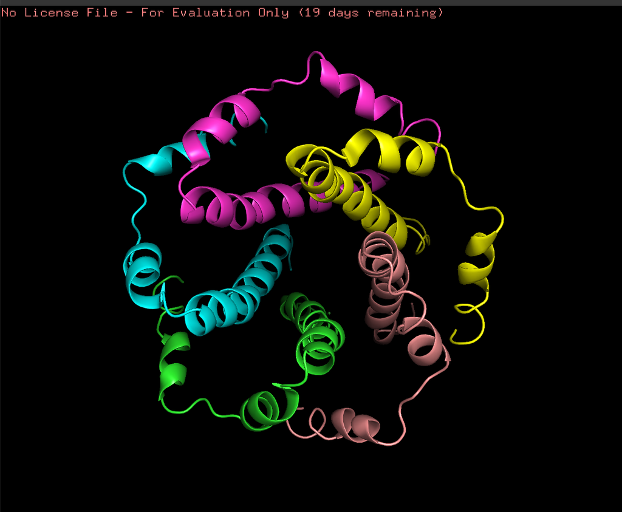

To compare both of the structures, I aligned them over each other based off matching chains. I did this using "align 7K3G,5X29" command. This overlayed the matching chains over one another to analyze matches. As can be seen below, there are many overlapping sections which proves that there is some form of similarity in the structure of the proteins that can be tested form using 3D protein measurements later. In this case, the blue color is the 5X29 protein and the green color is the 7K3G.

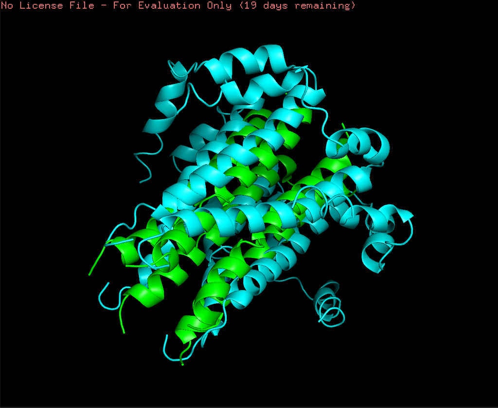

Here, I am using structural bioinformatics method of using nglview to showcase the structures of the envelope proteins. I imported two packages for this. First package was the Bio.PDB. This package is effective in being used for analyzing pdb structures and overall accessing such information. This will ultimately be used to activated the parser. The second package was nglview. This is a package used to access databases containing protein structures and print out 3D visualizations of such. To import this pip install nglview must be done first, but is already a part of my computer program so I did not include it here. They work in coordination with the pdb files. After importing the packages, the PDBparser command is ran as an empty function of be used in getting the desired structures. Using the parser, the .get_structure function is used to get both of the pdb's and store as variables of the cov2 and cov respectively. With thise variables, nv.show_biopython is used to display the structure. The parser command here is a global variable as is used in various parts, whiloe the rest are local pertaining to direct block.

```python
#importing Bio.PDB
from Bio.PDB import *
#importing nglview
import nglview as nv
```

```python
#creating the parser varibale by running empty function
parser = PDBParser()
```

```python
#saving the pdb structure for SARS-CoV-2
cov2_structure = parser.get_structure("7K3G", "7k3g.pdb")
#saving the pdb structure file for SARS-CoV
cov_structure = parser.get_structure("5x29", "5x29.pdb")
```

```python
#using nglview to display 3D structure of SARS-CoV-2 envelope protein
view = nv.show_biopython(cov2_structure)
view
```

```python
#using nglview to display 3D structure of SARS-CoV envelope protein
view = nv.show_biopython(cov_structure)
view
```

### Sequence Logos

Next, I am trying to develop the sequence logos. This is an example provided by the professor as my fasta files were incompatible with the sequence logos process. Sequence logos can be used to analyze sequence conservation of amino acids. This is a graphical representation based of the alignments of sequences. To begin, the logomaker package must first be installed. This is done below and is used to create the sequence logos. Logomaker seems to be a complex system method that helps to graphically illustrate the amino acid products. After installing logomaker, 4 packages must be imported. First, I imported numpy as np which can help with many of the mathematical analysis in python and creating functions based off such analysis. Second, I imported pandas as pd. This is useful to create a pandas dataframe and use such dataframe function to analyze the sequences in such manner. Next, I am importing mstplotlib.pyplot. This can be helpful to be used in creating plots in python and has many functions to create a variety of graphical representations. Lastly, I am importing the installed logomaker as lm. This is the program that will allow the creation of the sequence logos. The function library this provides analyses sequence alignments to form these sequence logos along the other imported packages. To do this, the alignment is used and turned into a functionality matrix. Using the dataframe created, we are then able to form a graphical representation of the amino acids present and their positions using the imported packages, especially logomaker.

```python
pip install logomaker
```

```
     |████████████████████████████████| 11.8 MB 3.5 MB/s eta 0:00:01
```

```python
#imported numpy package as np
import numpy as np
#imported pandas package as pd
import pandas as pd
#imported matplotlib.pyplot package as plt
import matplotlib.pyplot as plt
#imported logomaker package as lm
import logomaker as lm
```

```python
#this with command loads the alignment necessary for the sequence logos
with lm.open_example_datafile('ww_sequences.fa', print_description=False) as f:
    lines = f.readlines()
#printing the alignment that was loaded in
print(''.join(lines[:20]))
```

```
#
# WW domain alignment in FASTA format.
# From PFAM, RP15 (4025)
# http://pfam.xfam.org/family/PF00397#tabview=tab3
#
# References
#
# Finn RD et al. (2014) Pfam: the protein families database.
# Nucl Acids Res. 42(Database issue):D222–30.
#
>B7G9D5/250-280
LPPQW..TEA.VDVDT...GKFYFVHVET.......KETRWERP
>B7G9D5/328-356
--PGW..TAT.VDPAS...GRTYYYHAAT.......GETRWEPP
>B7G9D5/387-417
LPSGW..VEQ.TDPSS...GRPYYYHNAS.......NLTQWERP
>B7G9D5/503-533
LPAGW..VAA.NDPSS...GRTYYYHAES.......GVTSWNPP
>B7G9D5/626-656
LPNGW..QEL.VDPSS...GSTYYYNEVN.......GTTSWDRP
```

```python
#taking out the indiviudal sequences of this domain to analyze
seqs = [seq.strip().upper() for seq in lines if ('#' not in seq) and ('>') not in seq]
#print sequences
print('There are %d sequences, all of length %d'%(len(seqs), len(seqs[0])))
seqs[:10]
```

```
There are 4025 sequences, all of length 44
```

```
['LPPQW..TEA.VDVDT...GKFYFVHVET.......KETRWERP',
 '--PGW..TAT.VDPAS...GRTYYYHAAT.......GETRWEPP',
 'LPSGW..VEQ.TDPSS...GRPYYYHNAS.......NLTQWERP',
 'LPAGW..VAA.NDPSS...GRTYYYHAES.......GVTSWNPP',
 'LPNGW..QEL.VDPSS...GSTYYYNEVN.......GTTSWDRP',
 'LPEGW..VEL.VHESS...GKTYYFHAED.......NVTSWEQP',
 'LPQGW..IEA.VDPST...EATYYINEVE.......GITSWERP',
 'LPPGW..AKL.THPDS...GDAYYYNEAT.......NATSWDIP',
 '--TGW..EAL.VDEAS...GAIYYYNKLD.......GTSSWERP',
 'LPEGW..IEV.MDPNS...GSVYYFNEVD.......GTSSWDKP']
```

```python
#creating hte functionality matrix from the individual sequences
ww_counts_df = lm.alignment_to_matrix(sequences=seqs, to_type='counts', characters_to_ignore='.-X')
#printing the head count of the dataframe created using pandas
ww_counts_df.head()
```

| pos | A | C | D | E | F | G | H | I | K | L | M | N | P | Q | R | S | T | V | W | Y |
| --- | --- | --- | --- | --- | --- | --- | --- | --- | --- | --- | --- | --- | --- | --- | --- | --- | --- | --- | --- | --- |
| 0 | 0.0 | 0.0 | 0.0 | 0.0 | 0.0 | 0.0 | 0.0 | 0.0 | 0.0 | 2521.0 | 0.0 | 0.0 | 0.0 | 0.0 | 0.0 | 0.0 | 0.0 | 42.0 | 0.0 | 0.0 |
| 1 | 24.0 | 0.0 | 0.0 | 14.0 | 4.0 | 8.0 | 9.0 | 0.0 | 4.0 | 8.0 | 0.0 | 8.0 | 2651.0 | 15.0 | 2.0 | 9.0 | 2.0 | 1.0 | 0.0 | 0.0 |
| 2 | 319.0 | 56.0 | 280.0 | 425.0 | 21.0 | 62.0 | 57.0 | 7.0 | 76.0 | 60.0 | 9.0 | 64.0 | 999.0 | 94.0 | 40.0 | 365.0 | 106.0 | 35.0 | 3.0 | 70.0 |
| 3 | 112.0 | 0.0 | 201.0 | 149.0 | 6.0 | 2320.0 | 49.0 | 3.0 | 31.0 | 22.0 | 4.0 | 243.0 | 320.0 | 45.0 | 10.0 | 50.0 | 3.0 | 15.0 | 0.0 | 2.0 |
| 4 | 0.0 | 0.0 | 0.0 | 0.0 | 6.0 | 0.0 | 0.0 | 0.0 | 0.0 | 1.0 | 0.0 | 0.0 | 0.0 | 0.0 | 1.0 | 0.0 | 0.0 | 1.0 | 3880.0 | 48.0 |

```
<logomaker.src.Logo.Logo at 0x7fb7311f3430>
```

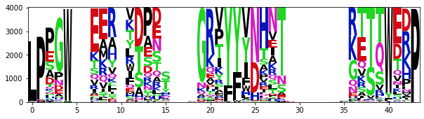

```python
#creates a sequence logos with the gaps in sequences present
lm.Logo(ww_counts_df)
```

```python
#filtering to close the gaps in graph
#setting variables each to modify the dataframe presented
num_seqs = ww_counts_df.sum(axis=1)
pos_to_keep = num_seqs > len(seqs)/2
ww_counts_df = ww_counts_df[pos_to_keep]
ww_counts_df.reset_index(drop=True, inplace=True)
```

```
<logomaker.src.Logo.Logo at 0x7fb7373efb80>
```

[figure not shown]

```python
#printing final result of sequence logos
lm.Logo(ww_counts_df)
```

### 3D Protein Measurements

3D protein measurements are different analytical methods of observing the structure of the protein based on mathetimatical variety between distances. One measurement is the distance between two alpha carbons based on the locations of the residues of a protein structure. To do this, the same imported packages as above were used such as numpy and PDBparser but were not included in the code as I did not want to included repeated code. First, I analyzed the SARS-CoV-2 structure by using the pdb parser function to access the protein. Using that, I assigned another variable for residues that utulized the .get_residues function to isolate the residues of the SARS-CoV-2 protein. I then seperated the two alpha carbons analyzes for a pair of residuals created to analyze the distance between them using the function provided in the print command below. This same process was used for the SARS-CoV protein. Doing so, I discovered that they have very similar distances between alpha carbons on their residuals with only a 0.005 difference. Then, for further analysis, I looked at the secondary structures of the proteins. In doing so, I looked for the fraction of amino acids found in each of the three classical secondary structures, alpha helixes, turns, and beta sheets (in that order). To do this in its entirety, I had to import the protein analysis package from bio.sequtils.protparam module. This enables a reading of the sequence reading and a protein analysis using the analyzed sequences. Before, I presented these percents on the secondary structure, I looked at the overall amino acid content by using the .get_amino_acids_percent() function from the protein analysis package. Using this, I was able to look at the amino acids present and understand what they were before seeing their distribution. Then, analyzing the secondary structure, I used the .secondary_structure_fraction() function in order to understand the amount of amino acids in each of the secondary structures. Doing so, I saw that they had no distinct similarities between the two envelope proteins. These are all global variables as they are not constricted by the limits of only one created function and can be used to analyze from any variable.

```python
#use the PDBparser to store the structure or SARS-CoV-2 protein
#set variable of structure as SARS2_structure
SARS2_structure = parser.get_structure("7K3G", "7K3G.pdb")
#get the residues using the .get_residues() function
residues2 = [r for r in SARS2_structure.get_residues()]
#seperating two pairs of residuals and alpha carbons to analyze
one  = residues2[0]["CA"].get_coord()
two = residues2[1]["CA"].get_coord()
#print distance between the alpha carbons for the pair of residuals
print('{} - {} = {}'.format(one,two, np.linalg.norm(one-two)))
```

```
[-0.829 -7.428  8.806] - [ 1.331 -9.573  6.529] = 3.8014936447143555
```

```python
#same process as above except variable names adjusted for SARS-CoV
SARS_structure = parser.get_structure("5X29", "5X29.pdb")

residues = [r for r in SARS_structure.get_residues()]
one  = residues[0]["CA"].get_coord()
two = residues[1]["CA"].get_coord()
print('{} - {} = {}'.format(one,two, np.linalg.norm(one-two)))
```

```
[-22.373  -5.394 -16.997] - [-25.822  -4.277 -18.158] = 3.8067338466644287
```

```python
#imported ProteinAnalysis package
from Bio.SeqUtils.ProtParam import ProteinAnalysis
```

```python
#create two variables using ProteinAnalysis function to store analyzed sequences
analyzed_cov2 = ProteinAnalysis(str('ETGTLIVNSVLLFLAFVVFLLVTLAILTALR'))
analyzed_cov = ProteinAnalysis(str('MHHHHHHSSGVDLGTENLYFQSMETGTLIVNSVLLFLAFVVFLLVTLAILTALRLAAYAANIVNVSLVKPTVYVYSRVKNL'))
```

```python
#use .get_amino_acis_percent() function with analyzed sequence of SARS-CoV-2 protein to view distribution of amino acids
analyzed_cov2.get_amino_acids_percent()
```

```
{'A': 0.0967741935483871,
 'C': 0.0,
 'D': 0.0,
 'E': 0.03225806451612903,
 'F': 0.0967741935483871,
 'G': 0.03225806451612903,
 'H': 0.0,
 'I': 0.06451612903225806,
 'K': 0.0,
 'L': 0.2903225806451613,
 'M': 0.0,
 'N': 0.03225806451612903,
 'P': 0.0,
 'Q': 0.0,
 'R': 0.03225806451612903,
 'S': 0.03225806451612903,
 'T': 0.12903225806451613,
 'V': 0.16129032258064516,
 'W': 0.0,
 'Y': 0.0}
```

```python
#use .get_amino_acis_percent() function with analyzed sequence of SARS-CoV protein to view distribution of amino acids
analyzed_cov.get_amino_acids_percent()
```

```
{'A': 0.08641975308641975,
 'C': 0.0,
 'D': 0.012345679012345678,
 'E': 0.024691358024691357,
 'F': 0.04938271604938271,
 'G': 0.037037037037037035,
 'H': 0.07407407407407407,
 'I': 0.037037037037037035,
 'K': 0.024691358024691357,
 'L': 0.1728395061728395,
 'M': 0.024691358024691357,
 'N': 0.06172839506172839,
 'P': 0.012345679012345678,
 'Q': 0.012345679012345678,
 'R': 0.024691358024691357,
 'S': 0.07407407407407407,
 'T': 0.07407407407407407,
 'V': 0.14814814814814814,
 'W': 0.0,
 'Y': 0.04938271604938271}
```

```python
#use .secondary_structure_fraction() function to analyze amino acid percent on each secondary structure protein
#in parathesis the order of structure goes: helix, turn, sheet
analyzed_cov2.secondary_structure_fraction()
```

```
(0.6129032258064516, 0.0967741935483871, 0.41935483870967744)
```

```python
#same as above except for SARS-CoV instead
analyzed_cov.secondary_structure_fraction()
```

```
(0.4567901234567901, 0.18518518518518517, 0.30864197530864196)
```